# 18. Wikipedia Application

## Wikipedia: Current Members of the US House of Representatives

### Building the Data

To start, let’s grab the text of a Wikipedia page that gives a list of all members of the U.S. House of Representatives:

```r
url_str <- modify_url(
  "https://en.wikipedia.org/w/api.php",
  query = list(
    action = "parse",
    format = "json",
    page = "List_of_current_members_of_the_United_States_House_of_Representatives"
  )
)
res <- http_cache_get(url_str, cache_dir = "cache")
obj_json <- content(res, type = "application/json")
```

We will focus today on the HTML data contained within the JSON pulled from the API:

```r
html_txt <- obj_json$parse$text[["*"]]
obj <- read_html(html_txt)
```

There are several tables on the Wikipedia page; we can get them all using an XPath expression:

```r
xml_find_all(obj, ".//table")
```

```
## {xml_nodeset (23)}
##  [1] <table class="sidebar nomobile nowraplinks plainlist" style="width:22.0em;">< ...
##  [2] <table class="sortable wikitable"><tbody>\n<tr>\n<th>Office\n</th>\n<th>Party ...
##  [3] <table class="sortable wikitable"><tbody>\n<tr>\n<th>Office\n</th>\n<th>Offic ...
##  [4] <table class="sortable wikitable"><tbody>\n<tr>\n<th>Office\n</th>\n<th>Offic ...
##  [5] <table class="wikitable sortable"><tbody>\n<tr>\n<th>\n<a href="/wiki/List_of ...
##  [6] <table class="wikitable sortable" style="text-align:center;"><tbody>\n<tr>\n< ...
##  [7] <table class="wikitable sortable" id="votingmembers"><tbody>\n<tr style="vert ...
##  [8] <table class="wikitable sortable" id="nonvotingmembers"><tbody>\n<tr style="v ...
##  [9] <table class="nowraplinks hlist mw-collapsible autocollapse navbox-inner" sty ...
## [10] <table class="nowraplinks mw-collapsible uncollapsed navbox-subgroup" style=" ...
## [11] <table class="nowraplinks navbox-subgroup" style="border-spacing:0"><tbody>\n ...
## [12] <table class="nowraplinks navbox-subgroup" style="border-spacing:0"><tbody>\n ...
## [13] <table class="nowraplinks navbox-subgroup" style="border-spacing:0"><tbody>\n ...
## [14] <table class="nowraplinks navbox-subgroup" style="border-spacing:0"><tbody>\n ...
## [15] <table class="nowraplinks mw-collapsible mw-collapsed navbox-subgroup" style= ...
## [16] <table class="nowraplinks navbox-subgroup" style="border-spacing:0"><tbody>\n ...
## [17] <table class="nowraplinks navbox-subgroup" style="border-spacing:0"><tbody><t ...
## [18] <table class="nowraplinks mw-collapsible mw-collapsed navbox-subgroup" style= ...
## [19] <table class="nowraplinks navbox-subgroup" style="border-spacing:0"><tbody>\n ...
## [20] <table class="nowraplinks navbox-subgroup" style="border-spacing:0"><tbody>\n ...
## ...
```

With some trial and error, we see that the table containing the voting members of the U.S. House can be found using the `id` attribute. Let’s save that here:

```r
mtable <- xml_find_all(obj, ".//table[@id='votingmembers']")
mtable
```

```
## {xml_nodeset (1)}
## [1] <table class="wikitable sortable" id="votingmembers"><tbody>\n<tr style="verti ...
```

The table contains a set of table headers, which are the column names of the table. These will help us as we parse apart the data.

```r
xml_find_all(mtable, ".//th")
```

```
## {xml_nodeset (8)}
## [1] <th>District\n</th>
## [2] <th>Member\n</th>
## [3] <th colspan="2">Party\n</th>
## [4] <th>Prior experience\n</th>
## [5] <th>Education\n</th>
## [6] <th>Assumed office\n</th>
## [7] <th>Residence\n</th>
## [8] <th>Born<sup id="cite_ref-born_3-0" class="reference"><a href="#cite_note-born ...
```

Each representative, in turn, is stored in a table row (`tr`) tag:

```r
rows <- xml_find_all(mtable, ".//tr")
rows
```

```
## {xml_nodeset (436)}
##  [1] <tr style="vertical-align:bottom">\n<th>District\n</th>\n<th>Member\n</th>\n< ...
##  [2] <tr>\n<td>\n<span data-sort-value="Alabama01 !"><a href="/wiki/Alabama%27s_1s ...
##  [3] <tr>\n<td>\n<span data-sort-value="Alabama02 !"><a href="/wiki/Alabama%27s_2n ...
##  [4] <tr>\n<td>\n<span data-sort-value="Alabama03 !"><a href="/wiki/Alabama%27s_3r ...
##  [5] <tr>\n<td>\n<span data-sort-value="Alabama04 !"><a href="/wiki/Alabama%27s_4t ...
##  [6] <tr>\n<td>\n<span data-sort-value="Alabama05 !"><a href="/wiki/Alabama%27s_5t ...
##  [7] <tr>\n<td>\n<span data-sort-value="Alabama06 !"><a href="/wiki/Alabama%27s_6t ...
##  [8] <tr>\n<td>\n<span data-sort-value="Alabama07 !"><a href="/wiki/Alabama%27s_7t ...
##  [9] <tr>\n<td>\n<span data-sort-value="AlaskaAL !"><a href="/wiki/Alaska%27s_at-l ...
## [10] <tr>\n<td>\n<span data-sort-value="Arizona01 !"><a href="/wiki/Arizona%27s_1s ...
## [11] <tr>\n<td>\n<span data-sort-value="Arizona02 !"><a href="/wiki/Arizona%27s_2n ...
## [12] <tr>\n<td>\n<span data-sort-value="Arizona03 !"><a href="/wiki/Arizona%27s_3r ...
## [13] <tr>\n<td>\n<span data-sort-value="Arizona04 !"><a href="/wiki/Arizona%27s_4t ...
## [14] <tr>\n<td>\n<span data-sort-value="Arizona05 !"><a href="/wiki/Arizona%27s_5t ...
## [15] <tr>\n<td>\n<span data-sort-value="Arizona06 !"><a href="/wiki/Arizona%27s_6t ...
## [16] <tr>\n<td>\n<span data-sort-value="Arizona07 !"><a href="/wiki/Arizona%27s_7t ...
## [17] <tr>\n<td>\n<span data-sort-value="Arizona08 !"><a href="/wiki/Arizona%27s_8t ...
## [18] <tr>\n<td>\n<span data-sort-value="Arizona09 !"><a href="/wiki/Arizona%27s_9t ...
## [19] <tr>\n<td>\n<span data-sort-value="Arkansas01 !"><a href="/wiki/Arkansas%27s_ ...
## [20] <tr>\n<td>\n<span data-sort-value="Arkansas02 !"><a href="/wiki/Arkansas%27s_ ...
## ...
```

Looking at one row, we see that the actual values is contained in table data (`td`) tags:

```r
xml_find_all(rows[2], ".//td")
```

```
## {xml_nodeset (9)}
## [1] <td>\n<span data-sort-value="Alabama01 !"><a href="/wiki/Alabama%27s_1st_congr ...
## [2] <td data-sort-value="Carl, Jerry">\n<a href="/wiki/File:Rep._Jerry_Carl_offici ...
## [3] <td style="background-color:#E81B23">\n</td>
## [4] <td>Republican\n</td>
## [5] <td>\n<a href="/wiki/Mobile_County,_Alabama" title="Mobile County, Alabama">Mo ...
## [6] <td>\n<a href="/wiki/Florida_Gateway_College" title="Florida Gateway College"> ...
## [7] <td>2021\n</td>
## [8] <td>\n<a href="/wiki/Mobile,_Alabama" title="Mobile, Alabama">Mobile</a>\n</td>
## [9] <td>\n<span style="display:none"> (<span class="bday">1958-06-17</span>) </spa ...
```

We can grab all of this data using a series of map functions. A few rows contain missing information (vacant seats); we can avoid these by selecting only those rows with a full 9 columns:

```r
ind <- which(map_int(rows, ~ length(xml_find_all(.x, "./td"))) == 9L)

df <- tibble(
  district =  map_chr(rows[ind] , ~ xml_text(xml_find_all(.x, "./td")[1], TRUE)),
  member =  map_chr(rows[ind] , ~ xml_text(xml_find_all(.x, "./td")[2], TRUE)),
  party =  map_chr(rows[ind] , ~ xml_text(xml_find_all(.x, "./td")[4], TRUE)),
  prior =  map_chr(rows[ind] , ~ xml_text(xml_find_all(.x, "./td")[5], TRUE)),
  education =  map_chr(rows[ind] , ~ xml_text(xml_find_all(.x, "./td")[6], TRUE)),
  assumed_office =  map_chr(rows[ind] , ~ xml_text(xml_find_all(.x, "./td")[7], TRUE)),
  residence =  map_chr(rows[ind] , ~ xml_text(xml_find_all(.x, "./td")[8], TRUE)),
  born =  map_chr(rows[ind] , ~ xml_text(xml_find_all(.x, "./td")[9], TRUE))
)

df
```

```
## # A tibble: 432 × 8
##    district        member  party  prior   education   assumed_office residence born
##    <chr>           <chr>   <chr>  <chr>   <chr>       <chr>          <chr>     <chr>
##  1 Alabama 1       Jerry … Repub… Mobile… Florida Ga… 2021           Mobile    (1958…
##  2 Alabama 2       Barry … Repub… Alabam… Enterprise… 2021           Enterpri… (1966…
##  3 Alabama 3       Mike R… Repub… Calhou… Jacksonvil… 2003           Anniston… (1958…
##  4 Alabama 4       Robert… Repub… Haleyv… University… 1997           Haleyvil… (1965…
##  5 Alabama 5       Mo Bro… Repub… Alabam… Duke Unive… 2011           Huntsvil… (1954…
##  6 Alabama 6       Gary P… Repub… Policy… University… 2015           Hoover    (1954…
##  7 Alabama 7       Terri … Democ… Attorn… Princeton … 2011           Birmingh… (1965…
##  8 Alaska at-large Don Yo… Repub… Ship c… Yuba Colle… 1973 (special) Fort Yuk… (1933…
##  9 Arizona 1       Tom O'… Democ… Arizon… Lewis Univ… 2017           Sedona    (1946…
## 10 Arizona 2       Ann Ki… Democ… U.S. H… University… 2019           Tucson    (1950…
## # … with 422 more rows
```

We now have a lot of structured data about the representatives, but what if we want to grab the links to the actual Wikipedia page themselves. We can do this by parsing the rows data in a different way:

```r
df$link <- rows[ind] %>%
  map(~xml_find_all(.x, "./td")[2]) %>%
  map(~xml_find_first(.x, ".//a[not(contains(@class,'image'))]")) %>%
  map_chr(~xml_attr(.x, "href")) %>%
  stri_sub(7L, -1L)
```

Finally, the data needs some cleaning:

```r
df <- df %>%
  mutate(assumed_year = as.numeric(stri_extract_first(assumed_office, regex = "[0-9]+"))) %>%
  mutate(born_date = ymd(stri_extract_first(born, regex = "[0-9]{4}-[0-9]{2}-[0-9]{2}"))) %>%
  mutate(state = stri_replace_all(district, "", regex = "[0-9]+")) %>%
  mutate(state = stri_replace_all(state, "", fixed = "at-large")) %>%
  mutate(state = stri_trim(state))
df
```

```
## # A tibble: 432 × 12
##    district  member  party  prior   education   assumed_office residence born   link
##    <chr>     <chr>   <chr>  <chr>   <chr>       <chr>          <chr>     <chr>  <chr>
##  1 Alabama 1 Jerry … Repub… Mobile… Florida Ga… 2021           Mobile    (1958… Jerr…
##  2 Alabama 2 Barry … Repub… Alabam… Enterprise… 2021           Enterpri… (1966… Barr…
##  3 Alabama 3 Mike R… Repub… Calhou… Jacksonvil… 2003           Anniston… (1958… Mike…
##  4 Alabama 4 Robert… Repub… Haleyv… University… 1997           Haleyvil… (1965… Robe…
##  5 Alabama 5 Mo Bro… Repub… Alabam… Duke Unive… 2011           Huntsvil… (1954… Mo_B…
##  6 Alabama 6 Gary P… Repub… Policy… University… 2015           Hoover    (1954… Gary…
##  7 Alabama 7 Terri … Democ… Attorn… Princeton … 2011           Birmingh… (1965… Terr…
##  8 Alaska a… Don Yo… Repub… Ship c… Yuba Colle… 1973 (special) Fort Yuk… (1933… Don_…
##  9 Arizona 1 Tom O'… Democ… Arizon… Lewis Univ… 2017           Sedona    (1946… Tom_…
## 10 Arizona 2 Ann Ki… Democ… U.S. H… University… 2019           Tucson    (1950… Ann_…
## # … with 422 more rows, and 3 more variables: assumed_year <dbl>, born_date <date>,
## #   state <chr>
```

### Exploratory Analysis

We can count the number of reps per state:

```r
df %>%
  group_by(state) %>%
  summarize(n = n()) %>%
  arrange(desc(n))
```

```
## # A tibble: 50 × 2
##    state              n
##    <chr>          <int>
##  1 California        53
##  2 Texas             36
##  3 New York          27
##  4 Florida           26
##  5 Illinois          18
##  6 Pennsylvania      18
##  7 Georgia           14
##  8 Michigan          14
##  9 Ohio              14
## 10 North Carolina    13
## # … with 40 more rows
```

And the average year of assuming office and birth date by party:

```r
df %>%
  group_by(party) %>%
  summarize(mean(assumed_year), mean(born_date))
```

```
## # A tibble: 2 × 3
##   party      `mean(assumed_year)` `mean(born_date)`
##   <chr>                     <dbl> <date>
## 1 Democratic                2011. 1961-05-05
## 2 Republican                2014. 1964-09-04
```

We can even look at the relationship between these two factors

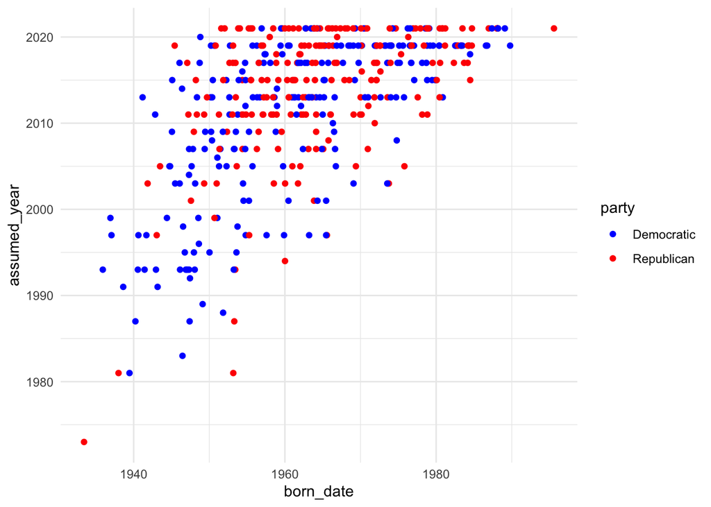

```r
df %>%
  ggplot(aes(born_date, assumed_year)) +
    geom_point(aes(color = party)) +
    scale_color_manual(values = c("Democratic" = "blue", "Republican" = "red"))
```

Going back to the original data, we can build a table of degrees earned:

```r
degree <- tibble(
  member = df$member,
  dname = map(rows[ind] , ~ xml_attr(xml_find_all(xml_find_all(.x, "./td")[6], ".//a"), "href"))
) %>%
  unnest(cols = c(dname)) %>%
  mutate(dname = stri_sub(dname, 7L, -1L))

degree
```

```
## # A tibble: 1,552 × 2
##    member      dname
##    <chr>       <chr>
##  1 Jerry Carl  Florida_Gateway_College
##  2 Barry Moore Enterprise_State_Community_College
##  3 Barry Moore Associate_degree
##  4 Barry Moore Auburn_University
##  5 Barry Moore Bachelor_of_Science
##  6 Mike Rogers Jacksonville_State_University
##  7 Mike Rogers Bachelor_of_Arts
##  8 Mike Rogers Master_of_Public_Administration
##  9 Mike Rogers Birmingham_School_of_Law
## 10 Mike Rogers Juris_Doctor
## # … with 1,542 more rows
```

Some of these are degree types and some are schools:

```r
degree_type <- degree %>%
  select(dname) %>%
  filter(stri_detect(dname, regex = "Associate") |
         stri_detect(dname, regex = "Bachelor") |
         stri_detect(dname, regex = "Master") |
         stri_detect(dname, regex = "Doctor")) %>%
  group_by(dname) %>%
  summarize(n = n()) %>%
  arrange(desc(n))

degree_type
```

```
## # A tibble: 40 × 2
##    dname                                 n
##    <chr>                             <int>
##  1 Bachelor_of_Arts                    288
##  2 Juris_Doctor                        138
##  3 Bachelor_of_Science                 117
##  4 Master_of_Arts                       50
##  5 Master_of_Business_Administration    39
##  6 Master_of_Science                    36
##  7 Master_of_Public_Administration      19
##  8 Doctor_of_Philosophy                 17
##  9 Doctor_of_Medicine                   13
## 10 Master_of_Public_Policy               9
## # … with 30 more rows
```

How do these distribute based on party?

```r
degree %>%
  semi_join(slice(degree_type, 1:10), by = "dname") %>%
  inner_join(df, by = "member") %>%
  group_by(party, dname) %>%
  summarize(n = n()) %>%
  pivot_wider(id_cols = dname, names_from = party, values_from = n, values_fill = 0L) %>%
  mutate(percent_dem = Democratic / (Democratic + Republican)) %>%
  arrange(desc(percent_dem))
```

```
## # A tibble: 10 × 4
##    dname                             Democratic Republican percent_dem
##    <chr>                                  <int>      <int>       <dbl>
##  1 Master_of_Public_Policy                    7          2       0.778
##  2 Doctor_of_Philosophy                      12          5       0.706
##  3 Master_of_Arts                            34         16       0.68
##  4 Juris_Doctor                              89         49       0.645
##  5 Bachelor_of_Arts                         182        106       0.632
##  6 Master_of_Public_Administration           11          8       0.579
##  7 Master_of_Science                         15         21       0.417
##  8 Master_of_Business_Administration         15         24       0.385
##  9 Bachelor_of_Science                       29         88       0.248
## 10 Doctor_of_Medicine                         3         10       0.231
```

And what is the most popular school in each state?

```r
degree %>%
  anti_join(degree_type, by = "dname") %>%
  inner_join(df, by = "member") %>%
  group_by(state, dname) %>%
  summarize(n = n()) %>%
  arrange(desc(n)) %>%
  slice(1) %>%
  filter(n > 2)
```

```
## # A tibble: 16 × 3
## # Groups:   state [16]
##    state          dname                                           n
##    <chr>          <chr>                                       <int>
##  1 Arizona        University_of_Arizona                           3
##  2 California     Harvard_University                              9
##  3 Florida        Florida_State_University                        7
##  4 Georgia        University_of_Georgia                           5
##  5 Louisiana      Louisiana_State_University                      3
##  6 Maryland       Harvard_University                              3
##  7 Massachusetts  Harvard_University                              4
##  8 Missouri       University_of_Missouri                          5
##  9 New York       Harvard_University                              4
## 10 North Carolina University_of_North_Carolina_at_Chapel_Hill     5
## 11 Ohio           Ohio_State_University                           3
## 12 Pennsylvania   Pennsylvania_State_University                   5
## 13 South Carolina University_of_South_Carolina                    3
## 14 Texas          University_of_Texas_at_Austin                   6
## 15 Washington     University_of_Washington                        5
## 16 Wisconsin      University_of_Wisconsin%E2%80%93Madison         3
```

### Page Views

Finally, let’s use iteration to see page views of each representative. Set a base url for the Wikipedia pageview API:

```r
url_base <- modify_url(
  "https://en.wikipedia.org/w/api.php",
  query = list(action = "query", format = "json", prop = "pageviews")
)
```

And then use the same code we had previously:

```r
output <- vector("list", nrow(df))

for (i in seq_along(df$link))
{
  url_str <- modify_url(url_base, query = list(titles = df$link[i]))
  res <- http_cache_get(url_str, cache_dir = "cache")

  stop_for_status(res)

  obj <- content(res, type = "application/json")
  output[[i]] <- tibble(
    page = obj$query$pages[[1]]$title,
    date = ymd(names(obj$query$pages[[1]]$pageviews)),
    views = map_int(obj$query$pages[[1]]$pageviews, ~ null_to_na(.x)),
    member = df$member[i]
  )
}

output <- bind_rows(output)
output
```

```
## # A tibble: 25,320 × 4
##    page       date       views member
##    <chr>      <date>     <int> <chr>
##  1 Jerry Carl 2021-08-27    81 Jerry Carl
##  2 Jerry Carl 2021-08-28    34 Jerry Carl
##  3 Jerry Carl 2021-08-29    60 Jerry Carl
##  4 Jerry Carl 2021-08-30    46 Jerry Carl
##  5 Jerry Carl 2021-08-31   104 Jerry Carl
##  6 Jerry Carl 2021-09-01   117 Jerry Carl
##  7 Jerry Carl 2021-09-02    85 Jerry Carl
##  8 Jerry Carl 2021-09-03   103 Jerry Carl
##  9 Jerry Carl 2021-09-04    39 Jerry Carl
## 10 Jerry Carl 2021-09-05    35 Jerry Carl
## # … with 25,310 more rows
```

From this data, we can find who has the most pageviews over the past 60 days:

```r
top_views <- output %>%
  group_by(member) %>%
  summarize(total_views = sum(views)) %>%
  arrange(desc(total_views)) %>%
  mutate(fmember = fct_inorder(member)) %>%
  inner_join(df, by = "member")

top_views
```

```
## # A tibble: 422 × 14
##    member total_views fmember district party prior education assumed_office residence
##    <chr>        <int> <fct>   <chr>    <chr> <chr> <chr>     <chr>          <chr>
##  1 Alexa…      577933 Alexan… New Yor… Demo… Bart… Boston U… 2019           The Bronx
##  2 Nancy…      446496 Nancy … Califor… Demo… Cali… Trinity … 1987 (special) San Fran…
##  3 Madis…      281041 Madiso… North C… Repu… Cong… Patrick … 2021           Henderso…
##  4 Marjo…      219378 Marjor… Georgia… Repu… Busi… Universi… 2021           Rome[26]
##  5 Liz C…      200512 Liz Ch… Wyoming… Repu… Prin… Colorado… 2017           Wilson[9…
##  6 Laure…      167495 Lauren… Colorad… Repu… Busi… –         2021           Silt
##  7 Prami…      151656 Pramil… Washing… Demo… Wash… Georgeto… 2017           Seattle
##  8 Ilhan…      137335 Ilhan … Minneso… Demo… Minn… North Da… 2019           Minneapo…
##  9 Matt …      130474 Matt G… Florida… Repu… Flor… Florida … 2017           Fort Wal…
## 10 Dan C…      124504 Dan Cr… Texas 2  Repu… U.S.… Tufts Un… 2019           Houston[…
## # … with 412 more rows, and 5 more variables: born <chr>, link <chr>,
## #   assumed_year <dbl>, born_date <date>, state <chr>
```

Or, the page view history over the past 60 days for the pages that were viewed the most:

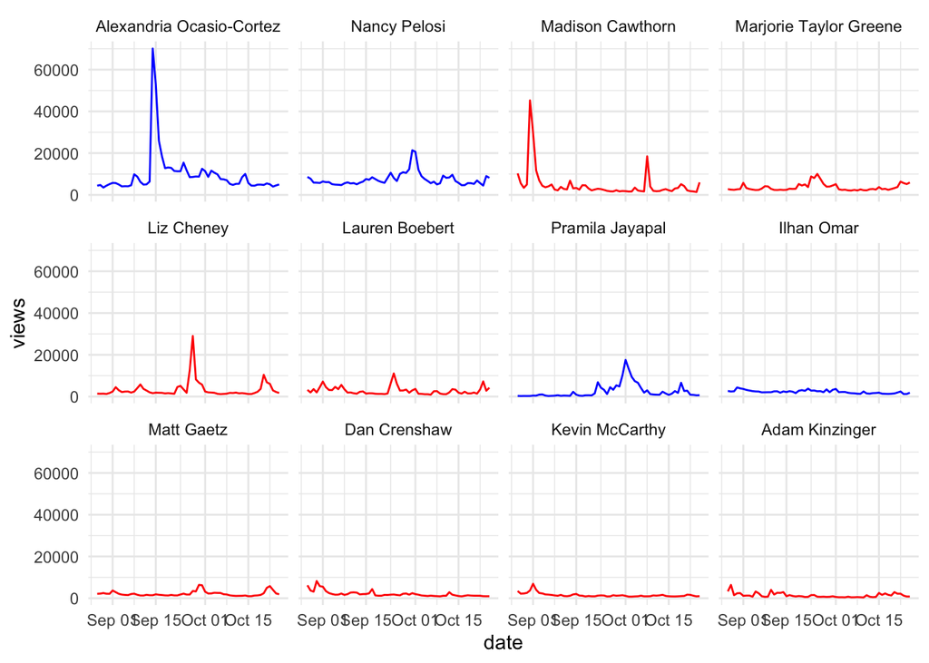

```r
output %>%
  inner_join(slice(top_views, seq_len(12L)), by = "member") %>%
  ggplot(aes(date, views)) +
    geom_line(aes(color = party), show.legend = FALSE) +
    facet_wrap(~fmember) +
    scale_color_manual(values = c("Democratic" = "blue", "Republican" = "red"))
```